# Part II - Ford GoBike Presentation

## by Chibuike Lawrence Orji-Oko

## Investigation Overview

> In this investigation, I wanted to learn more about the users, trip duration, what time and day of the week were most ride taken.

## Dataset Overview

> This is an exploration of the Ford GoBike dataset. The Ford GoBike Dataset consists of information about individual rides made in a bike-sharing system covering greater San Francisco. The data features include duration (secs), DateTime, customer type, gender, station name, and some additional variables.

## The Distribution of User Types

> Most of the Ford GoBike users are subscribers (89.2%).

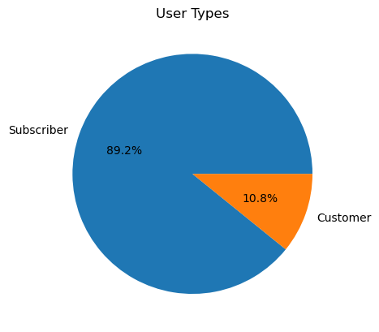

## Age Distribution of Users

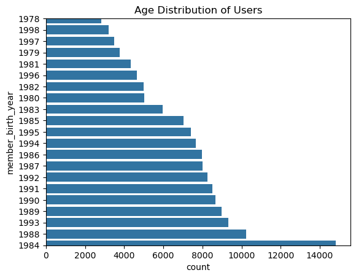

## Hourly Distribution of Rides

> The most busy hours are during the rush hours of a day, between the hours of 7AM and 9AM when people are going to work, and between the hours of 4PM and 6PM when people are returning back from work.

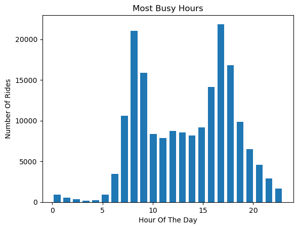

## Daily Distribution of Rides

> Thursdays have the hightest trips, followed by Tuedays. While weekends (Saturdays and Sundays) have the lowest rides.

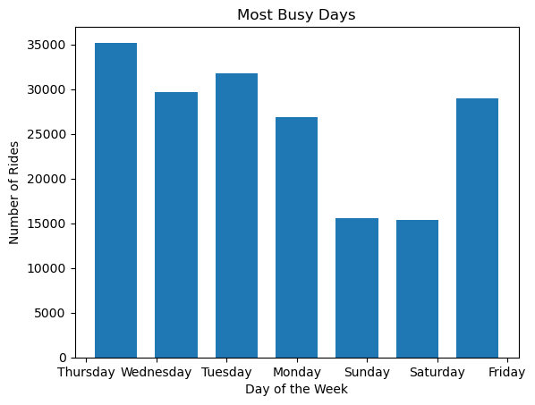

## Gender Distribution of Rides

> Most users are males. 75.74% of the users of the Ford GoBike system are males while 22.27% are females. Those that filled "other" as gender account for 1.99% of the total rides.

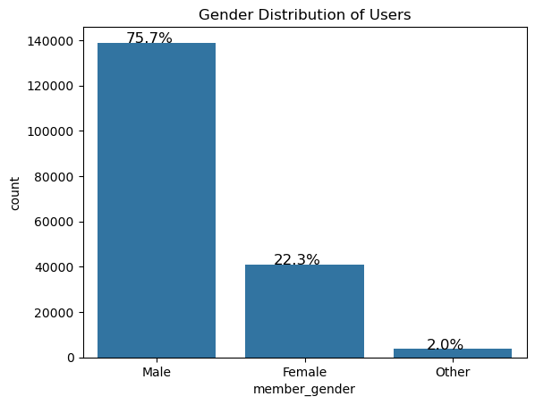

## Duration of Trips Duration

> There are a lot of rides on the short duration end (100 - 1000 secs) and few on the long duration end. It has a peak at around 500 secs and a gradual decline till around 10k secs. There are fewer longer durations afterwards between 10k secs and 100k secs. From the graph we can conclude that the majority of the rides are under 30 minutes.

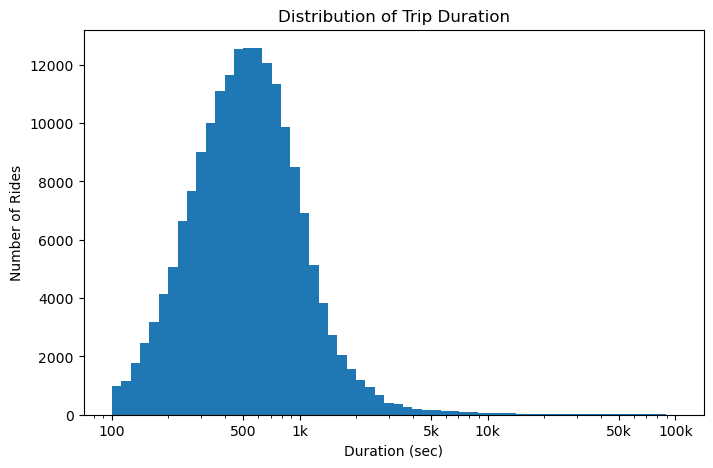

## The influence of bike-share on daily trip duration

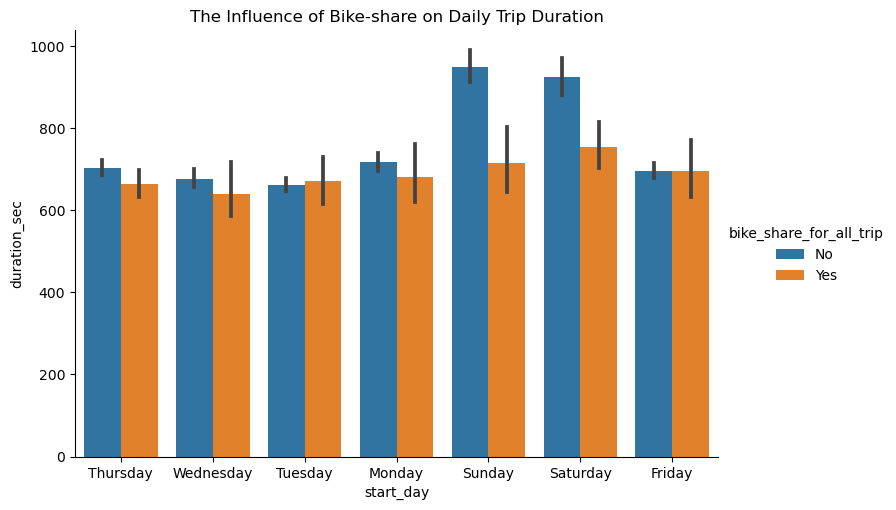

## Daily patronage of the two user types

> Customers on the average take longer trips than subscribers throuhgout the week but most on Saturdays and Sundays. While subscribers generally take shorter trips with litle increase during weekends

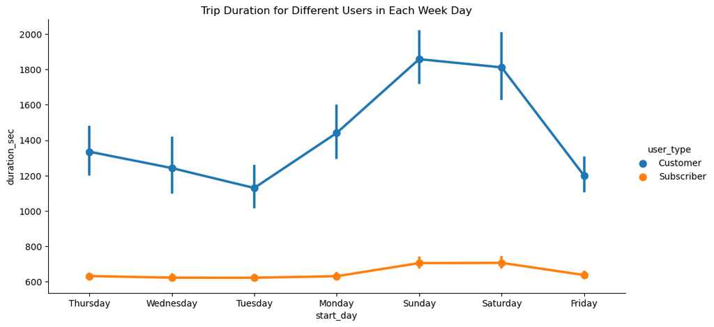

## Trip duration across gender for each week day

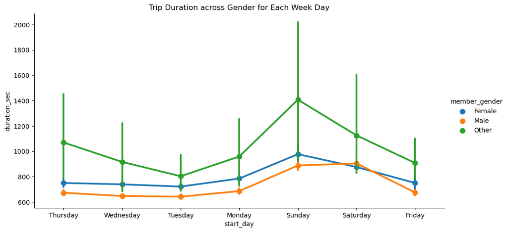